# N-mixture models with mvgam

Nicholas J Clark

2026-06-25

N-mixture models infer the true abundance of a closed population from repeated counts that are recorded with imperfect detection. The model partitions an observed count $y_{i, r}$ into a latent state (the unobserved abundance $N_i$ at site $i$) and a per-visit detection process that records each individual independently with probability $p_r$. This vignette walks through fitting the single-season Poisson-binomial N-mixture in `mvgam`, recovering the latent abundance against a known truth, and checking model fit with closure-unit-aware goodness-of-fit statistics. A two-species worked example carries the discussion; the same `bf(y ~ ..., p ~ ...)` formula extends to any number of species.

## N-mixture models

For an observation $y_{i, r}$ on site $i$ at visit $r$, the single-season Poisson-binomial N-mixture of [Royle (2004)](https://doi.org/10.1111/j.0006-341X.2004.00142.x) factors the data-generating process into a state layer and an observation layer:

$$\begin{align*}
y_{i, r} & \sim \text{Binomial}(N_i, p_r) \\
N_i & \sim \text{Poisson}(\lambda_i) \, .
\end{align*}$$

Covariates enter through the linear predictors for the abundance mean $\lambda_i$ (log link) and the detection probability $p_r$ (logit link):

$$\begin{align*}
\log \lambda_i & = \beta_0 + \beta^\top \mathbf{x}_i \\
\text{logit}\, p_r & = \gamma_0 + \gamma^\top \mathbf{q}_r \, .
\end{align*}$$

State and observation are conditionally independent given $N_i$. A single visit cannot identify $\lambda$ and $p$ separately, but replicated visits at the same site under the closure assumption let the binomial mean $N_i p_r$ and the binomial variance $N_i p_r (1 - p_r)$ jointly inform both parameters.

The latent $N_i$ is integer-valued, which leaves Hamiltonian Monte Carlo nothing to differentiate. `mvgam` handles this the same way the Stan documentation handles any discrete latent variable: the likelihood is marginalised analytically, summing over a finite range $N_i \in \{y_{i, \max}, \dots, K_{\max}\}$ where $K_{\max}$ is a per-site upper bound the user supplies (via the `cap` column). The chain only ever samples the continuous parameters on the right-hand side of the linear predictors. For a friendly walk-through of marginalising discrete parameters in Stan, see the chapter on [Latent Discrete Parameters in the Stan User’s Guide](https://mc-stan.org/docs/stan-users-guide/latent-discrete.html) and McElreath’s [Algebra and the Missing Oxen](https://elevanth.org/blog/2018/01/29/algebra-and-missingness/) walkthrough.

## Closure-unit data shape

Closure-unit families need the data in a long format that preserves the closure assumption: one row per `(species, site, visit)` cell, with the species identifier in `series`, the closure-unit identifier in `time`, the visit index in `visit`, the count in `y`, and the per-unit upper truncation for the marginalisation in `cap`. The columns are required because [`mvgam()`](https://nicholasjclark.github.io/mvgam/reference/mvgam.html) needs to align observations into the marginalised likelihood without the user pivoting to and from a multidimensional array.

The `sim_closure_unit_data()` helper generates a data frame in this shape together with the true generative parameters, so recovery checks read directly off `truth$lambda`, `truth$N`, `truth$p`, `truth$state_coefs`, and `truth$detection_coefs`. Each recipe carries a per-site state-level covariate set and a per-visit detection-level covariate set; recipe 1 uses a single covariate on each side (`env` on the state side, `tod_c` on the detection side) and is the cleanest entry point for an N-mixture example.

## A two-species worked example

Two species, 60 sites, four visits per site. Recipe 1 carries the site-level covariate `env ~ N(0, 1)` on the state side and the visit-level covariate `tod_c ~ U(-6, 6)` on the detection side. The simulator seeds the coefficient draws and the visit covariate values, returning the generative truth on `simdat$truth`.

```r
set.seed(0)
simdat <- sim_closure_unit_data(
  family    = nmix(),
  type      = 1L,
  n_species = 2L,
  n_sites   = 60L,
  n_visits  = 4L,
  seed      = 130L,
  K_max     = 30L
)
str(simdat$data_train)
```

```
#> 'data.frame':    480 obs. of  8 variables:
#>  $ visit : int  1 2 3 4 1 2 3 4 1 2 ...
#>  $ site  : int  1 1 1 1 2 2 2 2 3 3 ...
#>  $ series: Factor w/ 2 levels "sp_1","sp_2": 1 1 1 1 1 1 1 1 1 1 ...
#>  $ time  : int  1 1 1 1 2 2 2 2 3 3 ...
#>  $ y     : int  8 1 1 3 1 0 3 3 0 0 ...
#>  $ cap   : int  30 30 30 30 30 30 30 30 30 30 ...
#>  $ env   : num  1.65 1.65 1.65 1.65 -0.53 ...
#>  $ tod_c : num  -1.542 5.666 4.966 -0.586 -5.572 ...
```

```r
head(simdat$truth$state_coefs)
```

```
#>      intercept       env
#> [1,] 0.8771386 1.0154315
#> [2,] 0.2050035 0.1787785
```

```r
head(simdat$truth$detection_coefs)
```

```
#>       intercept      tod_c
#> [1,] -0.1906091 -0.3824334
#> [2,]  1.2143970 -0.3065838
```

The data frame is ready for [`mvgam()`](https://nicholasjclark.github.io/mvgam/reference/mvgam.html) without further manipulation. The truth bundle records the true per-species intercepts and slopes on the state side (`state_coefs`) and the detection side (`detection_coefs`), the true per-site expected abundance `lambda` and realised abundance `N`, and the true per-visit detection probability `p`. Recovery checks throughout the rest of the vignette point back to these slots.

### Fit

The fit combines two `brms`-style formulas inside a `bf()` call. The first arm gives the state-side linear predictor for $\log \lambda$; the second arm gives the detection-side linear predictor for $\text{logit}\, p$. Each arm includes a `series` main effect to estimate per-species intercepts plus an interaction with the covariate (`env:series`, `tod_c:series`) so each species gets its own slope:

```r
mod <- mvgam(
  formula = bf(y ~ series + env:series,
                p ~ series + tod_c:series),
  data    = simdat$data_train,
  family  = nmix(),
  chains  = 2L,
  samples = 500L,
  burnin  = 500L,
  silent  = 2L
)
```

```r
summary(mod, include_betas = FALSE)
```

```
#>  Family: nmix
#>   Links: mu = log
#> Formula: y ~ series + env:seriesp ~ series + tod_c:seriesNULLyNULL
#>    Data: simdat$data_train (Number of observations: 120)
#>  Series: 2
#>   Draws: 2 chains, each with iter = 1000; warmup = 500; thin = 1;
#>          total post-warmup draws = 2000
#>
#> == Observation Model ==
#> Population-Level Effects:
#>             Estimate Est.Error l-95% CI u-95% CI Rhat Bulk_ESS Tail_ESS
#> p[1]            0.94      0.23     0.51     1.39    1  1646.17  1524.61
#> p[2]           -0.39      0.03    -0.45    -0.33    1  2601.93  1124.24
#> p[3]           -0.31      0.05    -0.41    -0.22    1  1922.96  1666.69
#> Intercept       0.86      0.10     0.65     1.05    1  1721.95  1723.01
#> p_Intercept    -0.03      0.13    -0.29     0.22    1  2904.35  1654.30
#>
#> Coefficients for 'p':
#>           Estimate Est.Error l-95% CI u-95% CI Rhat Bulk_ESS Tail_ESS
#> Intercept    -0.03      0.13    -0.29     0.22    1  2904.35   1654.3
#>
#> Draws were sampled using sampling(NUTS). For each parameter, Bulk_ESS
#> and Tail_ESS are effective sample size measures, and Rhat is the potential
#> scale reduction factor on split chains (at convergence, Rhat = 1).
#>
#> Next steps:
#>   - `pp_check(fit, type = "fit_stat")`: closure-unit GOF p-value
#>   - `hindcast(fit, type = "latent_state")`: psi (occ) or N (nmix)
#>   - `forecast(fit, newdata = ...)`: out-of-sample forecasts
#>   - `loo(fit)` / `loo_compare(...)`: model fit + comparison
#>   - `conditional_effects(fit)`: covariate effects
#>   - `plot(hindcast(fit, type = "latent_state"))`: state ribbon
#> Use `how_to_cite(fit)` for a citation-ready model description.
```

The chain mixed cleanly: all R-hat values sit at 1.00 and bulk effective sample sizes reach into the thousands across the linear-predictor coefficients, so the posterior carries enough independent draws to support reliable inference about each species’ abundance and detection process. The next section checks how well the recovered coefficients match the simulator’s true parameters.

### Recovery against truth

`as.matrix(mod$fit)` exposes the posterior draws under the brms parameter names, which is what the recovery check uses. The `b[k]` indexing follows the column order of the design matrix that `mvgam()` built from the formula (`mod$standata$X` for the state side, `mod$standata$X_p` for the detection side):

```r
post <- as.matrix(mod$fit)
truth_state <- simdat$truth$state_coefs
truth_det   <- simdat$truth$detection_coefs

recovery <- data.frame(
  parameter = c("sp_1 log-lambda intercept",
                "sp_2 - sp_1 intercept",
                "sp_1 env slope",
                "sp_2 env slope",
                "sp_1 logit-p intercept",
                "sp_2 - sp_1 detection intercept",
                "sp_1 tod_c slope",
                "sp_2 tod_c slope"),
  truth     = c(truth_state[1, "intercept"],
                truth_state[2, "intercept"] -
                  truth_state[1, "intercept"],
                truth_state[1, "env"],
                truth_state[2, "env"],
                truth_det[1, "intercept"],
                truth_det[2, "intercept"] -
                  truth_det[1, "intercept"],
                truth_det[1, "tod_c"],
                truth_det[2, "tod_c"]),
  median    = c(median(post[, "Intercept"]),
                median(post[, "b[1]"]),
                median(post[, "b[2]"]),
                median(post[, "b[3]"]),
                median(post[, "Intercept_p"]),
                median(post[, "b_p[1]"]),
                median(post[, "b_p[2]"]),
                median(post[, "b_p[3]"]))
)
recovery$bias <- recovery$median - recovery$truth
recovery[, -1L] <- lapply(recovery[, -1L],
                           function(x) round(x, 2L))
recovery
```

[output not shown]

### Latent abundance: hindcast vs truth

The point of fitting an N-mixture is the latent abundance $N$, not the regression coefficients per se. `hindcast(mod, type = "latent_state")` returns the posterior at every closure unit as an `mvgam_latent_state` object that prints a short summary and hands back a tidy data frame through `summary()` (or its alias `as.data.frame()`):

```r
hc <- hindcast(mod, type = "latent_state")
print(hc)
```

```
#> Posterior latent state at training units
#>   Family:           nmix
#>   State:            Latent abundance (N)
#>   Series:           2 (sp_1, sp_2)
#>   Units:            120
#>   Posterior draws:  2000
#>   Median N range: [0, 29]
#>   (No time dimension: 'time' is the closure-unit index.)
```

```r
head(as.data.frame(hc), 6)
```

```
#>   series time median lower_50 upper_50 lower_95 upper_95
#> 1   sp_1    1     10        9       11        8       13
#> 2   sp_1    2      3        3        3        3        3
#> 3   sp_1    3      1        1        1        1        2
#> 4   sp_1    4      0        0        0        0        0
#> 5   sp_1    5      3        3        3        3        3
#> 6   sp_1    6      2        1        2        1        3
```

`plot()` on the same object returns a ggplot ribbon (step-style for integer-valued `N`) faceted by species. Because the output is a plain ggplot, the simulator truth can be overlaid as a points layer with `+ geom_point()` without writing any plotting code by hand:

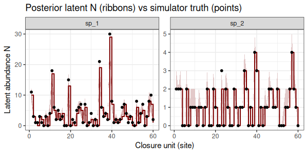

```r
truth_long <- data.frame(
  series = factor(rep(c("sp_1", "sp_2"), each = 60L),
                  levels = c("sp_1", "sp_2")),
  time   = rep(seq_len(60L), 2L),
  true_N = c(simdat$truth$N[1L, ], simdat$truth$N[2L, ])
)
plot(hc) +
  geom_point(data = truth_long,
              aes(x = time, y = true_N),
              colour = "black", size = 1.3) +
  labs(x = "Closure unit (site)",
        y = expression("Latent abundance " * N),
        title = "Posterior latent N (ribbons) vs simulator truth (points)")
```

Almost every truth point sits inside the 95% credible ribbon and most sit inside the 50% ribbon. Two diagnostics quantify what the figure shows:

```r
smry <- as.data.frame(hc)
merged <- merge(smry, truth_long, by = c("series", "time"))
mean(merged$true_N >= merged$lower_50 &
       merged$true_N <= merged$upper_50)
```

```
#> [1] 0.8666667
```

```r
mean(merged$true_N >= merged$lower_95 &
       merged$true_N <= merged$upper_95)
```

```
#> [1] 0.975
```

### Covariate effects on abundance and detection

`conditional_effects()` returns a partial-effect plot per covariate-by-species combination on the response scale. Because `y` is a count from the N-mixture, the response scale is the expected count $\mathbb{E}[Y] = \lambda \cdot p$ per visit; covariate slopes on $\lambda$ and on $p$ both contribute. To read each side separately, the `marginaleffects` interface exposes the closure-unit `latent_state` and `detection` types directly:

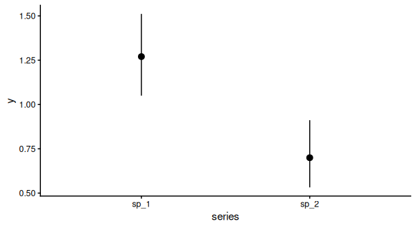

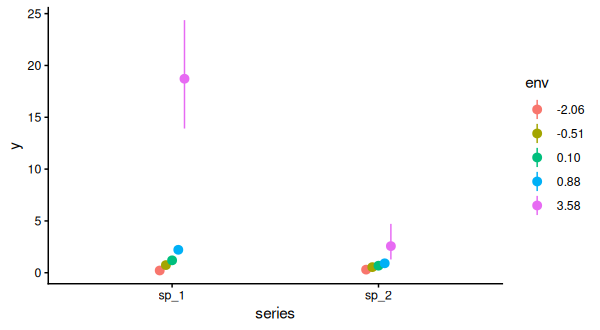

```r
conditional_effects(mod)
```

`conditional_effects()` puts both species on the same panel by mixing their marginal expected counts. To inspect detection probability on its native probability scale, with each species on its own curve, `marginaleffects::plot_predictions()` with `type = "detection"` reads the per-visit detection process out of the fit and plots it directly:

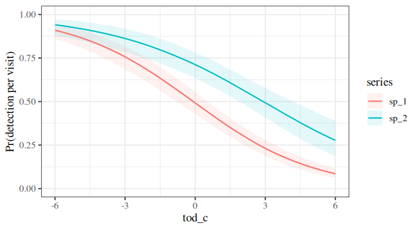

```r
marginaleffects::plot_predictions(
  mod,
  condition = c("tod_c", "series"),
  type      = "detection"
) +
  ylab("Pr(detection per visit)") +
  ylim(c(0, 1))
```

### Goodness-of-fit: closure-unit Bayesian p-values

`pp_check(type = "fit_stat")` runs the [MacKenzie and Bailey (2004)](https://doi.org/10.1198/108571104X3361) closure-unit goodness-of-fit test. The statistic collapses the visit-level counts within each closure unit to a sufficient discrepancy (chi-squared by default; Freeman-Tukey as an alternative that handles small counts better), then compares the observed discrepancy to its posterior predictive distribution. A Bayesian p-value near 0.5 means the observed discrepancy is typical under the model; values near 0 or 1 indicate that the model under-disperses or over-disperses the observed counts.

```r
pp_check(mod, type = "fit_stat", stat = "chi_squared",
          ndraws = 200L)
```

```
#> Posterior predictive check (closure-unit discrepancy)
#>   Family:           nmix
#>   Statistic:        chi-squared
#>   Aggregation:      closure unit
#>   Posterior draws:  200
#>   Bayesian p-value: 0.570
```

The chi-squared Bayesian p-value lands in the centre of the null distribution, well away from 0 or 1. The model’s per-unit predicted counts span the same range of dispersion as the observed counts, so there is no sign that the Binomial-Poisson mixture is over- or under-dispersing the data. Chi-squared weights every cell equally and can react harshly to the small counts that closure-unit data typically carry, so the Freeman-Tukey discrepancy is the natural cross-check:

```r
pp_check(mod, type = "fit_stat", stat = "freeman_tukey",
          ndraws = 200L)
```

```
#> Posterior predictive check (closure-unit discrepancy)
#>   Family:           nmix
#>   Statistic:        Freeman-Tukey
#>   Aggregation:      closure unit
#>   Posterior draws:  200
#>   Bayesian p-value: 0.365
```

The Freeman-Tukey p-value also lands away from the boundaries. Both discrepancies agree. The closure-unit likelihood is describing both the hidden abundance process and the per-visit detection layer well, even with the modest intercept bias the recovery table documented, and the latent abundance coverage shown earlier confirms it.

## Alternative observation processes

The Poisson-binomial assumption that detection is an independent Bernoulli trial for each of $N$ individuals is the most common N-mixture formulation, but it is not the only one. `nmix()` exposes two further variants chosen by the `type` argument; the Stan implementation marginalises latent $N$ for each of them and the post-fit surface (latent-state hindcast, detection predictions, GOF) carries through unchanged.

| Variant | Constructor | Detection scale | When to prefer |
| --- | --- | --- | --- |
| Poisson-binomial | `nmix()` | logit $p$ per visit | Default. Direct Royle (2004) parameterisation; cleanest interpretation when individuals are independently detectable. |
| Royle-Nichols | `nmix("royle_nichols")` | log $r$ per individual | Repeated presence-absence rather than counts. Heterogeneous detection across individuals collapses into a per-individual hazard $r$; the binary observation arises from $1 - (1 - r)^N$. |
| Poisson-Poisson | `nmix("poisson_poisson")` | log $\rho$ per visit | Encounter-rate data where the observed count is a noisy Poisson realisation of an underlying Poisson encounter rate, with no a-priori detection ceiling. |

Switching variants is a one-line change in the `family` argument; the data shape and formula stay the same.

```r
mod_rn  <- mvgam(formula = bf(y ~ series + env:series,
                                 p ~ series + tod_c:series),
                 data    = simdat$data_train,
                 family  = nmix("royle_nichols"),
                 chains  = 2L, samples = 500L,
                 burnin  = 500L, silent = 2L)

mod_ppm <- mvgam(formula = bf(y ~ series + env:series,
                                 p ~ series + tod_c:series),
                 data    = simdat$data_train,
                 family  = nmix("poisson_poisson"),
                 chains  = 2L, samples = 500L,
                 burnin  = 500L, silent = 2L)
```

The Royle-Nichols variant follows Royle and Nichols (2003); the Poisson-Poisson variant is the encounter-rate parameterisation adopted for `mvgam`. See `?nmix` for the constructor’s full argument list, including the `multi_season` opt-in for fits with a real seasonal axis.

## Where to next

- `?nmix` for the constructor’s family-specific dpars, identification caveats, and the per-variant kernel references.
- `?occ` for the single-season occupancy family that shares the closure-unit data shape with `nmix`.
- `?sim_closure_unit_data` for the simulator’s recipe catalogue and the `truth$` bundle layout.
- `?jsdgam` for joint species distribution fits with a latent factor structure (`n_lv > 0`) on the abundance side, useful when residual cross-species correlation needs explicit modelling.
- The [overview vignette](https://nicholasjclark.github.io/mvgam/articles/mvgam_overview.html) for the state-space architecture that the closure-unit families fit into.

## Further reading

Knape, J. and Korner-Nievergelt, F. (2015). Estimates from non-replicated population surveys rely on critical assumptions. *Methods in Ecology and Evolution* 6, 902-906. [doi:10.1111/2041-210X.12377](https://doi.org/10.1111/2041-210X.12377)

MacKenzie, D. I. and Bailey, L. L. (2004). Assessing the fit of site-occupancy models. *Journal of Agricultural, Biological, and Environmental Statistics* 9, 300-318. [doi:10.1198/108571104X3361](https://doi.org/10.1198/108571104X3361)

McElreath, R. (2018). [Algebra and the Missing Oxen](https://elevanth.org/blog/2018/01/29/algebra-and-missingness/). *Elements of Evolutionary Anthropology* (blog).

Royle, J. A. (2004). N-mixture models for estimating population size from spatially replicated counts. *Biometrics* 60, 108-115. [doi:10.1111/j.0006-341X.2004.00142.x](https://doi.org/10.1111/j.0006-341X.2004.00142.x)

Royle, J. A. and Nichols, J. D. (2003). Estimating abundance from repeated presence-absence data or point counts. *Ecology* 84(3), 777-790. DOI: https://doi.org/10.1890/0012-9658(2003)084[0777:EAFRPA]2.0.CO;2

Stan Development Team (2024). [Latent Discrete Parameters](https://mc-stan.org/docs/stan-users-guide/latent-discrete.html). *Stan User’s Guide*.